# 🤖⚡ scikit-learn tip #1:

Use ColumnTransformer to apply different preprocessing to different columns:

- select from DataFrame columns by name
- passthrough or drop unspecified columns

Requires scikit-learn 0.20+

See example 👇

```python
import pandas as pd
df = pd.read_csv('http://bit.ly/kaggletrain', nrows=6)
```

```python
cols = ['Fare', 'Embarked', 'Sex', 'Age']
X = df[cols]
```

```python
X
```

|  | Fare | Embarked | Sex | Age |
| --- | --- | --- | --- | --- |
| 0 | 7.2500 | S | male | 22.0 |
| 1 | 71.2833 | C | female | 38.0 |
| 2 | 7.9250 | S | female | 26.0 |
| 3 | 53.1000 | S | female | 35.0 |
| 4 | 8.0500 | S | male | 35.0 |
| 5 | 8.4583 | Q | male | NaN |

```python
from sklearn.preprocessing import OneHotEncoder
from sklearn.impute import SimpleImputer
from sklearn.compose import make_column_transformer
```

```python
ohe = OneHotEncoder()
imp = SimpleImputer()
```

```python
ct = make_column_transformer(
    (ohe, ['Embarked', 'Sex']),  # apply OneHotEncoder to Embarked and Sex
    (imp, ['Age']),              # apply SimpleImputer to Age
    remainder='passthrough')     # include remaining column (Fare) in the output
```

```python
# column order: Embarked (3 columns), Sex (2 columns), Age (1 column), Fare (1 column)
ct.fit_transform(X)
```

```
array([[ 0.    ,  0.    ,  1.    ,  0.    ,  1.    , 22.    ,  7.25  ],
       [ 1.    ,  0.    ,  0.    ,  1.    ,  0.    , 38.    , 71.2833],
       [ 0.    ,  0.    ,  1.    ,  1.    ,  0.    , 26.    ,  7.925 ],
       [ 0.    ,  0.    ,  1.    ,  1.    ,  0.    , 35.    , 53.1   ],
       [ 0.    ,  0.    ,  1.    ,  0.    ,  1.    , 35.    ,  8.05  ],
       [ 0.    ,  1.    ,  0.    ,  0.    ,  1.    , 31.2   ,  8.4583]])
```

### Want more tips? [View all tips on GitHub](https://github.com/justmarkham/scikit-learn-tips) or [Sign up to receive 5 tips by email every week](https://scikit-learn.tips) 💌

© 2020 [Data School](https://www.dataschool.io). All rights reserved.

# 🤖⚡ scikit-learn tip #2:

There are SEVEN ways to select columns using ColumnTransformer:

1. column name
2. integer position
3. slice
4. boolean mask
5. regex pattern
6. dtypes to include
7. dtypes to exclude

See example 👇

```python
import pandas as pd
df = pd.read_csv('http://bit.ly/kaggletrain', nrows=6)
```

```python
cols = ['Fare', 'Embarked', 'Sex', 'Age']
X = df[cols]
```

```python
X
```

|  | Fare | Embarked | Sex | Age |
| --- | --- | --- | --- | --- |
| 0 | 7.2500 | S | male | 22.0 |
| 1 | 71.2833 | C | female | 38.0 |
| 2 | 7.9250 | S | female | 26.0 |
| 3 | 53.1000 | S | female | 35.0 |
| 4 | 8.0500 | S | male | 35.0 |
| 5 | 8.4583 | Q | male | NaN |

```python
from sklearn.preprocessing import OneHotEncoder
from sklearn.compose import make_column_transformer  # new in 0.20
from sklearn.compose import make_column_selector     # new in 0.22
```

```python
ohe = OneHotEncoder()
```

```python
# all SEVEN of these produce the same results
ct = make_column_transformer((ohe, ['Embarked', 'Sex']))
ct = make_column_transformer((ohe, [1, 2]))
ct = make_column_transformer((ohe, slice(1, 3)))
ct = make_column_transformer((ohe, [False, True, True, False]))
ct = make_column_transformer((ohe, make_column_selector(pattern='E|S')))
ct = make_column_transformer((ohe, make_column_selector(dtype_include=object)))
ct = make_column_transformer((ohe, make_column_selector(dtype_exclude='number')))
```

```python
# one-hot encode Embarked and Sex (and drop all other columns)
ct.fit_transform(X)
```

```
array([[0., 0., 1., 0., 1.],
       [1., 0., 0., 1., 0.],
       [0., 0., 1., 1., 0.],
       [0., 0., 1., 1., 0.],
       [0., 0., 1., 0., 1.],
       [0., 1., 0., 0., 1.]])
```

### Want more tips? [View all tips on GitHub](https://github.com/justmarkham/scikit-learn-tips) or [Sign up to receive 5 tips by email every week](https://scikit-learn.tips) 💌

© 2020 [Data School](https://www.dataschool.io). All rights reserved.

# 🤖⚡ scikit-learn tip #6:

Two common ways to encode categorical features:

- OneHotEncoder for unordered (nominal) data
- OrdinalEncoder for ordered (ordinal) data

See example 👇

P.S. LabelEncoder is for labels, not features!

```python
import pandas as pd
X = pd.DataFrame({'Shape':['square', 'square', 'oval', 'circle'],
                  'Class': ['third', 'first', 'second', 'third'],
                  'Size': ['S', 'S', 'L', 'XL']})
```

```python
# "Shape" is unordered, "Class" and "Size" are ordered
X
```

|  | Shape | Class | Size |
| --- | --- | --- | --- |
| 0 | square | third | S |
| 1 | square | first | S |
| 2 | oval | second | L |
| 3 | circle | third | XL |

```python
from sklearn.preprocessing import OneHotEncoder, OrdinalEncoder
```

```python
# left-to-right column order is alphabetical (circle, oval, square)
ohe = OneHotEncoder(sparse=False)
ohe.fit_transform(X[['Shape']])
```

```
array([[0., 0., 1.],
       [0., 0., 1.],
       [0., 1., 0.],
       [1., 0., 0.]])
```

```python
# category ordering (within each feature) is defined by you
oe = OrdinalEncoder(categories=[['first', 'second', 'third'], ['S', 'M', 'L', 'XL']])
oe.fit_transform(X[['Class', 'Size']])
```

```
array([[2., 0.],
       [0., 0.],
       [1., 2.],
       [2., 3.]])
```

### Want more tips? [View all tips on GitHub](https://github.com/justmarkham/scikit-learn-tips) or [Sign up to receive 5 tips by email every week](https://scikit-learn.tips) 💌

© 2020 [Data School](https://www.dataschool.io). All rights reserved.

# 🤖⚡ scikit-learn tip #7:

Q: For a one-hot encoded feature, what can you do if new data contains categories that weren't seen during training?

A: Set handle_unknown='ignore' to encode new categories as all zeros.

See example 👇

P.S. If you know all possible categories that might ever appear, you can instead specify the categories manually. handle_unknown='ignore' is useful specifically when you don't know all possible categories.

```python
import pandas as pd
X = pd.DataFrame({'col':['A', 'B', 'C', 'B']})
X_new = pd.DataFrame({'col':['A', 'C', 'D']})
```

```python
from sklearn.preprocessing import OneHotEncoder
ohe = OneHotEncoder(sparse=False, handle_unknown='ignore')
```

```python
X
```

|  | col |
| --- | --- |
| 0 | A |
| 1 | B |
| 2 | C |
| 3 | B |

```python
# three columns represent categories A, B, and C
ohe.fit_transform(X[['col']])
```

```
array([[1., 0., 0.],
       [0., 1., 0.],
       [0., 0., 1.],
       [0., 1., 0.]])
```

```python
# category D was not learned by OneHotEncoder during the "fit" step
X_new
```

|  | col |
| --- | --- |
| 0 | A |
| 1 | C |
| 2 | D |

```python
# category D is encoded as all zeros
ohe.transform(X_new[['col']])
```

```
array([[1., 0., 0.],
       [0., 0., 1.],
       [0., 0., 0.]])
```

### Want more tips? [View all tips on GitHub](https://github.com/justmarkham/scikit-learn-tips) or [Sign up to receive 5 tips by email every week](https://scikit-learn.tips) 💌

© 2020 [Data School](https://www.dataschool.io). All rights reserved.

# 🤖⚡ scikit-learn tip #8:

Q: What does "pipeline" do?

A: Chains together multiple steps: output of each step is used as input to the next step.

Makes it easy to apply the same preprocessing to train and test!

See example 👇

```python
import pandas as pd
import numpy as np
```

```python
train = pd.DataFrame({'feat1':[10, 20, np.nan, 2], 'feat2':[25., 20, 5, 3], 'label':['A', 'A', 'B', 'B']})
test = pd.DataFrame({'feat1':[30., 5, 15], 'feat2':[12, 10, np.nan]})
```

```python
from sklearn.impute import SimpleImputer
from sklearn.linear_model import LogisticRegression
from sklearn.pipeline import make_pipeline
```

```python
imputer = SimpleImputer()
clf = LogisticRegression()
```

```python
# 2-step pipeline: impute missing values, then pass the results to the classifier
pipe = make_pipeline(imputer, clf)
```

```python
train
```

|  | feat1 | feat2 | label |
| --- | --- | --- | --- |
| 0 | 10.0 | 25.0 | A |
| 1 | 20.0 | 20.0 | A |
| 2 | NaN | 5.0 | B |
| 3 | 2.0 | 3.0 | B |

```python
test
```

|  | feat1 | feat2 |
| --- | --- | --- |
| 0 | 30.0 | 12.0 |
| 1 | 5.0 | 10.0 |
| 2 | 15.0 | NaN |

```python
features = ['feat1', 'feat2']
```

```python
X, y = train[features], train['label']
X_new = test[features]
```

```python
# pipeline applies the imputer to X before fitting the classifier
pipe.fit(X, y)

# pipeline applies the imputer to X_new before making predictions
# note: pipeline uses imputation values learned during the "fit" step
pipe.predict(X_new)
```

```
array(['A', 'B', 'A'], dtype=object)
```

### Want more tips? [View all tips on GitHub](https://github.com/justmarkham/scikit-learn-tips) or [Sign up to receive 5 tips by email every week](https://scikit-learn.tips) 💌

© 2020 [Data School](https://www.dataschool.io). All rights reserved.

# 🤖⚡ scikit-learn tip #9:

When imputing missing values, you can preserve info about which values were missing and use THAT as a feature!

Why? Sometimes there's a relationship between "missingness" and the target/label you are trying to predict.

See example 👇

```python
import pandas as pd
import numpy as np
```

```python
X = pd.DataFrame({'Age':[20, 30, 10, np.nan, 10]})
```

```python
X
```

|  | Age |
| --- | --- |
| 0 | 20.0 |
| 1 | 30.0 |
| 2 | 10.0 |
| 3 | NaN |
| 4 | 10.0 |

```python
from sklearn.impute import SimpleImputer
```

```python
# impute the mean
imputer = SimpleImputer()
imputer.fit_transform(X)
```

```
array([[20. ],
       [30. ],
       [10. ],
       [17.5],
       [10. ]])
```

```python
# impute the mean and add an indicator matrix (new in 0.21)
imputer = SimpleImputer(add_indicator=True)
imputer.fit_transform(X)
```

```
array([[20. ,  0. ],
       [30. ,  0. ],
       [10. ,  0. ],
       [17.5,  1. ],
       [10. ,  0. ]])
```

### Want more tips? [View all tips on GitHub](https://github.com/justmarkham/scikit-learn-tips) or [Sign up to receive 5 tips by email every week](https://scikit-learn.tips) 💌

© 2020 [Data School](https://www.dataschool.io). All rights reserved.

# 🤖⚡ scikit-learn tip #10:

Q: Why set a value for "random_state"?

A: Ensures that a "random" process will output the same results every time, which makes your code reproducible (by you and others!)

See example 👇

```python
import pandas as pd
df = pd.read_csv('http://bit.ly/kaggletrain', nrows=6)
```

```python
cols = ['Fare', 'Embarked', 'Sex']
X = df[cols]
y = df['Survived']
```

```python
from sklearn.model_selection import train_test_split
```

```python
X
```

|  | Fare | Embarked | Sex |
| --- | --- | --- | --- |
| 0 | 7.2500 | S | male |
| 1 | 71.2833 | C | female |
| 2 | 7.9250 | S | female |
| 3 | 53.1000 | S | female |
| 4 | 8.0500 | S | male |
| 5 | 8.4583 | Q | male |

```python
# any positive integer can be used for the random_state value
X_train, X_test, y_train, y_test = train_test_split(X, y, test_size=0.5, random_state=1)
X_train
```

|  | Fare | Embarked | Sex |
| --- | --- | --- | --- |
| 0 | 7.2500 | S | male |
| 3 | 53.1000 | S | female |
| 5 | 8.4583 | Q | male |

```python
# using the SAME random_state value results in the SAME random split
X_train, X_test, y_train, y_test = train_test_split(X, y, test_size=0.5, random_state=1)
X_train
```

|  | Fare | Embarked | Sex |
| --- | --- | --- | --- |
| 0 | 7.2500 | S | male |
| 3 | 53.1000 | S | female |
| 5 | 8.4583 | Q | male |

```python
# using a DIFFERENT random_state value results in a DIFFERENT random split
X_train, X_test, y_train, y_test = train_test_split(X, y, test_size=0.5, random_state=2)
X_train
```

|  | Fare | Embarked | Sex |
| --- | --- | --- | --- |
| 2 | 7.9250 | S | female |
| 5 | 8.4583 | Q | male |
| 0 | 7.2500 | S | male |

### Want more tips? [View all tips on GitHub](https://github.com/justmarkham/scikit-learn-tips) or [Sign up to receive 5 tips by email every week](https://scikit-learn.tips) 💌

© 2020 [Data School](https://www.dataschool.io). All rights reserved.

# 🤖⚡ scikit-learn tip #11:

Need something better than SimpleImputer for missing value imputation?

Try KNNImputer or IterativeImputer (inspired by R's MICE package). Both are multivariate approaches (they take other features into account!)

See example 👇

```python
import pandas as pd
df = pd.read_csv('http://bit.ly/kaggletrain', nrows=6)
```

```python
cols = ['SibSp', 'Fare', 'Age']
X = df[cols]
```

```python
X
```

|  | SibSp | Fare | Age |
| --- | --- | --- | --- |
| 0 | 1 | 7.2500 | 22.0 |
| 1 | 1 | 71.2833 | 38.0 |
| 2 | 0 | 7.9250 | 26.0 |
| 3 | 1 | 53.1000 | 35.0 |
| 4 | 0 | 8.0500 | 35.0 |
| 5 | 0 | 8.4583 | NaN |

```python
# new in 0.21, and still "experimental" so it must be enabled explicitly
from sklearn.experimental import enable_iterative_imputer
from sklearn.impute import IterativeImputer
```

```python
impute_it = IterativeImputer()
impute_it.fit_transform(X)
```

```
array([[ 1.        ,  7.25      , 22.        ],
       [ 1.        , 71.2833    , 38.        ],
       [ 0.        ,  7.925     , 26.        ],
       [ 1.        , 53.1       , 35.        ],
       [ 0.        ,  8.05      , 35.        ],
       [ 0.        ,  8.4583    , 28.50639495]])
```

```python
# new in 0.22
from sklearn.impute import KNNImputer
```

```python
impute_knn = KNNImputer(n_neighbors=2)
impute_knn.fit_transform(X)
```

```
array([[ 1.    ,  7.25  , 22.    ],
       [ 1.    , 71.2833, 38.    ],
       [ 0.    ,  7.925 , 26.    ],
       [ 1.    , 53.1   , 35.    ],
       [ 0.    ,  8.05  , 35.    ],
       [ 0.    ,  8.4583, 30.5   ]])
```

### Want more tips? [View all tips on GitHub](https://github.com/justmarkham/scikit-learn-tips) or [Sign up to receive 5 tips by email every week](https://scikit-learn.tips) 💌

© 2020 [Data School](https://www.dataschool.io). All rights reserved.

# 🤖⚡ scikit-learn tip #12:

Q: What's the difference between Pipeline and make_pipeline?

A: Pipeline requires naming of steps, make_pipeline does not.

(Same applies to ColumnTransformer vs make_column_transformer)

See example 👇

```python
import pandas as pd
df = pd.read_csv('http://bit.ly/kaggletrain', nrows=6)
```

```python
cols = ['Embarked', 'Sex', 'Age', 'Fare']
X = df[cols]
```

```python
from sklearn.preprocessing import OneHotEncoder
from sklearn.impute import SimpleImputer
from sklearn.linear_model import LogisticRegression
```

```python
ohe = OneHotEncoder()
imp = SimpleImputer()
clf = LogisticRegression()
```

```python
from sklearn.compose import make_column_transformer
from sklearn.pipeline import make_pipeline
```

```python
ct = make_column_transformer(
    (ohe, ['Embarked', 'Sex']),
    (imp, ['Age']),
    remainder='passthrough')
```

```python
pipe = make_pipeline(ct, clf)
```

```python
from sklearn.compose import ColumnTransformer
from sklearn.pipeline import Pipeline
```

```python
ct = ColumnTransformer(
    [('encoder', ohe, ['Embarked', 'Sex']),
     ('imputer', imp, ['Age'])],
    remainder='passthrough')
```

```python
pipe = Pipeline([('preprocessor', ct), ('classifier', clf)])
```

### Want more tips? [View all tips on GitHub](https://github.com/justmarkham/scikit-learn-tips) or [Sign up to receive 5 tips by email every week](https://scikit-learn.tips) 💌

© 2020 [Data School](https://www.dataschool.io). All rights reserved.

# 🤖⚡ scikit-learn tip #13:

Q: How do you examine the intermediate steps in a Pipeline?

A: By using the "named_steps" attribute:

pipe.named_steps.STEP_NAME.ATTRIBUTE

See example 👇

```python
import pandas as pd
df = pd.read_csv('http://bit.ly/kaggletrain', nrows=6)
df = df[['Age', 'Pclass', 'Survived']]
```

```python
df
```

|  | Age | Pclass | Survived |
| --- | --- | --- | --- |
| 0 | 22.0 | 3 | 0 |
| 1 | 38.0 | 1 | 1 |
| 2 | 26.0 | 3 | 1 |
| 3 | 35.0 | 1 | 1 |
| 4 | 35.0 | 3 | 0 |
| 5 | NaN | 3 | 0 |

```python
X = df[['Age', 'Pclass']]
y = df['Survived']
```

```python
from sklearn.impute import SimpleImputer
from sklearn.linear_model import LogisticRegression
from sklearn.pipeline import make_pipeline
```

```python
pipe = make_pipeline(SimpleImputer(), LogisticRegression())
```

```python
# use semicolon to suppress output in IPython
pipe.fit(X, y);
```

```python
# display the imputation values for "Age" and "Pclass"
pipe.named_steps.simpleimputer.statistics_
```

```
array([31.2       ,  2.33333333])
```

```python
# display the model coefficients for "Age" and "Pclass"
pipe.named_steps.logisticregression.coef_
```

```
array([[ 0.03232238, -0.83741131]])
```

### Want more tips? [View all tips on GitHub](https://github.com/justmarkham/scikit-learn-tips) or [Sign up to receive 5 tips by email every week](https://scikit-learn.tips) 💌

© 2020 [Data School](https://www.dataschool.io). All rights reserved.

# 🤖⚡ scikit-learn tip #14:

Four options for handling missing values (NaNs):

1. Drop rows containing NaNs
2. Drop columns containing NaNs
3. Fill NaNs with imputed values
4. Use a model that natively handles NaNs (NEW!)

See example 👇

```python
import pandas as pd
train = pd.read_csv('http://bit.ly/kaggletrain')
test = pd.read_csv('http://bit.ly/kaggletest', nrows=175)
```

```python
train = train[['Survived', 'Age', 'Fare', 'Pclass']]
test = test[['Age', 'Fare', 'Pclass']]
```

```python
# count the number of NaNs in each column
train.isna().sum()
```

```
Survived      0
Age         177
Fare          0
Pclass        0
dtype: int64
```

```python
test.isna().sum()
```

```
Age       36
Fare       1
Pclass     0
dtype: int64
```

```python
label = train.pop('Survived')
```

```python
# new in 0.22: this estimator (experimental) has native support for NaNs
from sklearn.experimental import enable_hist_gradient_boosting
from sklearn.ensemble import HistGradientBoostingClassifier
```

```python
clf = HistGradientBoostingClassifier()
```

```python
# no errors, despite NaNs in train and test!
clf.fit(train, label)
clf.predict(test)
```

```
array([0, 0, 0, 1, 0, 0, 0, 0, 0, 0, 0, 0, 1, 0, 0, 1, 0, 1, 1, 0, 1, 0,
       1, 1, 1, 0, 1, 1, 1, 0, 1, 1, 0, 0, 1, 0, 0, 0, 0, 1, 0, 0, 0, 0,
       1, 0, 0, 0, 1, 1, 1, 0, 1, 0, 0, 0, 0, 0, 1, 1, 0, 1, 0, 1, 1, 0,
       1, 0, 0, 1, 0, 0, 0, 0, 1, 1, 0, 0, 0, 0, 1, 0, 1, 0, 1, 0, 1, 1,
       0, 1, 0, 0, 1, 0, 1, 0, 1, 0, 0, 0, 1, 0, 0, 0, 0, 0, 0, 0, 0, 0,
       0, 0, 1, 0, 1, 0, 0, 1, 1, 1, 1, 0, 1, 0, 0, 0, 0, 1, 1, 0, 0, 0,
       0, 0, 0, 0, 0, 0, 0, 0, 0, 1, 1, 1, 1, 0, 1, 0, 0, 1, 1, 0, 0, 0,
       0, 0, 1, 0, 1, 0, 0, 1, 0, 0, 1, 0, 1, 0, 0, 0, 0, 0, 0, 0, 0])
```

### Want more tips? [View all tips on GitHub](https://github.com/justmarkham/scikit-learn-tips) or [Sign up to receive 5 tips by email every week](https://scikit-learn.tips) 💌

© 2020 [Data School](https://www.dataschool.io). All rights reserved.

# 🤖⚡ scikit-learn tip #16:

You can cross-validate and grid search an entire pipeline!

Preprocessing steps will automatically occur AFTER each cross-validation split, which is critical if you want meaningful scores.

See example 👇

```python
import pandas as pd
df = pd.read_csv('http://bit.ly/kaggletrain')
```

```python
cols = ['Sex', 'Name']
X = df[cols]
y = df['Survived']
```

```python
from sklearn.preprocessing import OneHotEncoder
from sklearn.feature_extraction.text import CountVectorizer
from sklearn.compose import make_column_transformer
```

```python
ohe = OneHotEncoder()
vect = CountVectorizer()
ct = make_column_transformer((ohe, ['Sex']), (vect, 'Name'))
```

```python
from sklearn.linear_model import LogisticRegression
clf = LogisticRegression(solver='liblinear', random_state=1)
```

```python
from sklearn.pipeline import make_pipeline
pipe = make_pipeline(ct, clf)
```

## Cross-validate the entire pipeline (not just the model)

```python
from sklearn.model_selection import cross_val_score
cross_val_score(pipe, X, y, cv=5, scoring='accuracy').mean()
```

```
0.8024543343167408
```

## Find optimal tuning parameters for the entire pipeline

```python
# specify parameter values to search
params = {}
params['columntransformer__countvectorizer__min_df'] = [1, 2]
params['logisticregression__C'] = [0.1, 1, 10]
params['logisticregression__penalty'] = ['l1', 'l2']
```

```python
# try all possible combinations of those parameter values
from sklearn.model_selection import GridSearchCV
grid = GridSearchCV(pipe, params, cv=5, scoring='accuracy')
grid.fit(X, y);
```

```python
# what was the best score found during the search?
grid.best_score_
```

```
0.8226413909986817
```

```python
# which combination of parameters produced the best score?
grid.best_params_
```

```
{'columntransformer__countvectorizer__min_df': 1,
 'logisticregression__C': 10,
 'logisticregression__penalty': 'l1'}
```

### Want more tips? [View all tips on GitHub](https://github.com/justmarkham/scikit-learn-tips) or [Sign up to receive 5 tips by email every week](https://scikit-learn.tips) 💌

© 2020 [Data School](https://www.dataschool.io). All rights reserved.

# 🤖⚡ scikit-learn tip #17:

GridSearchCV taking too long? Try RandomizedSearchCV with a small number of iterations.

Make sure to specify a distribution (instead of a list of values) for continuous parameters!

See example 👇

```python
import pandas as pd
df = pd.read_csv('http://bit.ly/kaggletrain')
```

```python
# use single brackets around "Name" because CountVectorizer expects 1-D input
X = df['Name']
y = df['Survived']
```

```python
from sklearn.feature_extraction.text import CountVectorizer
from sklearn.naive_bayes import MultinomialNB
from sklearn.pipeline import make_pipeline
```

```python
pipe = make_pipeline(CountVectorizer(), MultinomialNB())
```

```python
# cross-validate the pipeline using default parameters
from sklearn.model_selection import cross_val_score
cross_val_score(pipe, X, y, cv=5, scoring='accuracy').mean()
```

```
0.8001820350260498
```

```python
# specify parameter values to search (use a distribution for any continuous parameters)
import scipy as sp
params = {}
params['countvectorizer__min_df'] = [1, 2, 3, 4]
params['countvectorizer__lowercase'] = [True, False]
params['multinomialnb__alpha'] = sp.stats.uniform(scale=1)
```

```python
# try "n_iter" random combinations of those parameter values
from sklearn.model_selection import RandomizedSearchCV
rand = RandomizedSearchCV(pipe, params, n_iter=10, cv=5, scoring='accuracy', random_state=1)
rand.fit(X, y);
```

```python
# what was the best score found during the search?
rand.best_score_
```

```
0.8080534806352395
```

```python
# which combination of parameters produced the best score?
rand.best_params_
```

```
{'countvectorizer__lowercase': False,
 'countvectorizer__min_df': 3,
 'multinomialnb__alpha': 0.1981014890848788}
```

### Want more tips? [View all tips on GitHub](https://github.com/justmarkham/scikit-learn-tips) or [Sign up to receive 5 tips by email every week](https://scikit-learn.tips) 💌

© 2020 [Data School](https://www.dataschool.io). All rights reserved.

# 🤖⚡ scikit-learn tip #18:

Hyperparameter search results (from GridSearchCV or RandomizedSearchCV) can be converted into a pandas DataFrame.

Makes it far easier to explore the results!

See example 👇

```python
import pandas as pd
df = pd.read_csv('http://bit.ly/kaggletrain')
```

```python
X = df[['Pclass', 'Sex', 'Name']]
y = df['Survived']
```

```python
from sklearn.preprocessing import OneHotEncoder
from sklearn.feature_extraction.text import CountVectorizer
from sklearn.linear_model import LogisticRegression
from sklearn.compose import make_column_transformer
from sklearn.pipeline import Pipeline
```

```python
ohe = OneHotEncoder()
vect = CountVectorizer()
clf = LogisticRegression(solver='liblinear', random_state=1)
```

```python
ct = make_column_transformer((ohe, ['Sex']), (vect, 'Name'), remainder='passthrough')
pipe = Pipeline([('preprocessor', ct), ('model', clf)])
```

```python
# specify parameter values to search
params = {}
params['model__C'] = [0.1, 1, 10]
params['model__penalty'] = ['l1', 'l2']
```

```python
# try all possible combinations of those parameter values
from sklearn.model_selection import GridSearchCV
grid = GridSearchCV(pipe, params, cv=5, scoring='accuracy')
grid.fit(X, y);
```

```python
# convert results into a DataFrame
results = pd.DataFrame(grid.cv_results_)[['params', 'mean_test_score', 'rank_test_score']]
```

```python
# sort by test score
results.sort_values('rank_test_score')
```

|  | params | mean_test_score | rank_test_score |
| --- | --- | --- | --- |
| 2 | {'model__C': 1, 'model__penalty': 'l1'} | 0.821512 | 1 |
| 4 | {'model__C': 10, 'model__penalty': 'l1'} | 0.820413 | 2 |
| 5 | {'model__C': 10, 'model__penalty': 'l2'} | 0.817055 | 3 |
| 3 | {'model__C': 1, 'model__penalty': 'l2'} | 0.812573 | 4 |
| 1 | {'model__C': 0.1, 'model__penalty': 'l2'} | 0.791225 | 5 |
| 0 | {'model__C': 0.1, 'model__penalty': 'l1'} | 0.788984 | 6 |

### Want more tips? [View all tips on GitHub](https://github.com/justmarkham/scikit-learn-tips) or [Sign up to receive 5 tips by email every week](https://scikit-learn.tips) 💌

© 2020 [Data School](https://www.dataschool.io). All rights reserved.

# 🤖⚡ scikit-learn tip #20:

New in scikit-learn 0.22: Plot a confusion matrix in one line of code!

Highly customizable, including the colormap, display labels, and value formatting.

See example 👇

```python
import pandas as pd
df = pd.read_csv('http://bit.ly/kaggletrain')
```

```python
cols = ['Pclass', 'Fare']
X = df[cols]
y = df['Survived']
```

```python
from sklearn.model_selection import train_test_split
from sklearn.linear_model import LogisticRegression
from sklearn.metrics import plot_confusion_matrix
```

```python
X_train, X_test, y_train, y_test = train_test_split(X, y, random_state=0)
```

```python
clf = LogisticRegression()
clf.fit(X_train, y_train);
```

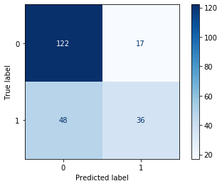

```python
# pass it a trained model: it makes predictions for X_test and compares them to y_test
disp = plot_confusion_matrix(clf, X_test, y_test, cmap='Blues', values_format='d')
```

```python
# print the "normal" confusion matrix
disp.confusion_matrix
```

```
array([[122,  17],
       [ 48,  36]])
```

### Want more tips? [View all tips on GitHub](https://github.com/justmarkham/scikit-learn-tips) or [Sign up to receive 5 tips by email every week](https://scikit-learn.tips) 💌

© 2020 [Data School](https://www.dataschool.io). All rights reserved.

# 🤖⚡ scikit-learn tip #21:

New in scikit-learn 0.22: Easily compare multiple ROC curves in a single plot!

Automatically displays the AUC for each model as well.

See example 👇

```python
import pandas as pd
df = pd.read_csv('http://bit.ly/kaggletrain')
```

```python
cols = ['Pclass', 'Fare', 'SibSp']
X = df[cols]
y = df['Survived']
```

```python
from sklearn.model_selection import train_test_split
from sklearn.linear_model import LogisticRegression
from sklearn.tree import DecisionTreeClassifier
from sklearn.ensemble import RandomForestClassifier
from sklearn.metrics import plot_roc_curve
```

```python
X_train, X_test, y_train, y_test = train_test_split(X, y, random_state=0)
```

```python
lr = LogisticRegression()
dt = DecisionTreeClassifier()
rf = RandomForestClassifier()
```

```python
lr.fit(X_train, y_train);
dt.fit(X_train, y_train);
rf.fit(X_train, y_train);
```

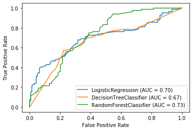

```python
disp = plot_roc_curve(lr, X_test, y_test)
plot_roc_curve(dt, X_test, y_test, ax=disp.ax_);
plot_roc_curve(rf, X_test, y_test, ax=disp.ax_);
```

### Want more tips? [View all tips on GitHub](https://github.com/justmarkham/scikit-learn-tips) or [Sign up to receive 5 tips by email every week](https://scikit-learn.tips) 💌

© 2020 [Data School](https://www.dataschool.io). All rights reserved.

# 🤖⚡ scikit-learn tip #23:

Q: How do you display the intercept & coefficients for a linear model?

A: They are stored as attributes of the model: `intercept_` and `coef_`

Attributes end with `_` if they are set during "fit"

See example 👇

```python
from sklearn.datasets import load_diabetes
dataset = load_diabetes()
```

```python
X, y = dataset.data, dataset.target
features = dataset.feature_names
```

```python
from sklearn.linear_model import LinearRegression
model = LinearRegression()
model.fit(X, y);
```

```python
model.intercept_
```

```
152.1334841628965
```

```python
model.coef_
```

```
array([ -10.01219782, -239.81908937,  519.83978679,  324.39042769,
       -792.18416163,  476.74583782,  101.04457032,  177.06417623,
        751.27932109,   67.62538639])
```

```python
# display the feature names with the coefficients
list(zip(features, model.coef_))
```

```
[('age', -10.012197817470962),
 ('sex', -239.81908936565566),
 ('bmi', 519.8397867901349),
 ('bp', 324.39042768937657),
 ('s1', -792.1841616283053),
 ('s2', 476.7458378236622),
 ('s3', 101.04457032134493),
 ('s4', 177.06417623225025),
 ('s5', 751.2793210873947),
 ('s6', 67.62538639104369)]
```

### Want more tips? [View all tips on GitHub](https://github.com/justmarkham/scikit-learn-tips) or [Sign up to receive 5 tips by email every week](https://scikit-learn.tips) 💌

© 2020 [Data School](https://www.dataschool.io). All rights reserved.

# 🤖⚡ scikit-learn tip #24:

Two new functions in scikit-learn 0.21 for visualizing decision trees:

1. plot_tree: uses Matplotlib (not Graphviz!)
2. export_text: doesn't require any external libraries

See examples 👇

```python
import pandas as pd
df = pd.read_csv('http://bit.ly/kaggletrain')
df['Sex'] = df['Sex'].map({'male':0, 'female':1})
```

```python
features = ['Pclass', 'Fare', 'Sex']
X = df[features]
y = df['Survived']
```

```python
classes = ['Deceased', 'Survived']
```

```python
from sklearn.tree import DecisionTreeClassifier
dt = DecisionTreeClassifier(max_depth=2, random_state=0)
dt.fit(X, y);
```

```python
import matplotlib.pyplot as plt
from sklearn.tree import plot_tree, export_text  # both are new in 0.21
```

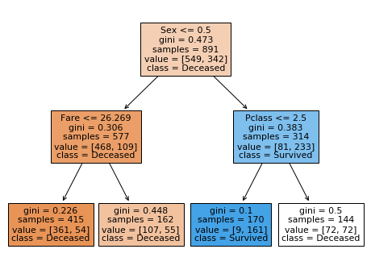

```python
plt.figure(figsize=(8, 6))
plot_tree(dt, feature_names=features, class_names=classes, filled=True);
```

```python
print(export_text(dt, feature_names=features, show_weights=True))
```

```
|--- Sex <= 0.50
|   |--- Fare <= 26.27
|   |   |--- weights: [361.00, 54.00] class: 0
|   |--- Fare >  26.27
|   |   |--- weights: [107.00, 55.00] class: 0
|--- Sex >  0.50
|   |--- Pclass <= 2.50
|   |   |--- weights: [9.00, 161.00] class: 1
|   |--- Pclass >  2.50
|   |   |--- weights: [72.00, 72.00] class: 0
```

### Want more tips? [View all tips on GitHub](https://github.com/justmarkham/scikit-learn-tips) or [Sign up to receive 5 tips by email every week](https://scikit-learn.tips) 💌

© 2020 [Data School](https://www.dataschool.io). All rights reserved.

# 🤖⚡ scikit-learn tip #25:

New in scikit-learn 0.22: Pruning of decision trees to avoid overfitting!

- Uses cost-complexity pruning
- Increase "ccp_alpha" to increase pruning (default value is 0)

See example 👇

```python
import pandas as pd
df = pd.read_csv('http://bit.ly/kaggletrain')
df['Sex'] = df['Sex'].map({'male':0, 'female':1})
```

```python
features = ['Pclass', 'Fare', 'Sex', 'Parch']
X = df[features]
y = df['Survived']
```

```python
from sklearn.tree import DecisionTreeClassifier
from sklearn.model_selection import cross_val_score
```

```python
# default tree has 331 nodes
dt = DecisionTreeClassifier(random_state=0)
dt.fit(X, y).tree_.node_count
```

```
331
```

```python
cross_val_score(dt, X, y, cv=5, scoring='accuracy').mean()
```

```
0.8036281463812692
```

```python
# pruned tree has 121 nodes
dt = DecisionTreeClassifier(ccp_alpha=0.001, random_state=0)
dt.fit(X, y).tree_.node_count
```

```
121
```

```python
# pruning improved the cross-validated accuracy
cross_val_score(dt, X, y, cv=5, scoring='accuracy').mean()
```

```
0.8081162513338773
```

### Want more tips? [View all tips on GitHub](https://github.com/justmarkham/scikit-learn-tips) or [Sign up to receive 5 tips by email every week](https://scikit-learn.tips) 💌

© 2020 [Data School](https://www.dataschool.io). All rights reserved.

# 🤖⚡ scikit-learn tip #26:

Are you using train_test_split with a classification problem?

Be sure to set "stratify=y" so that class proportions are preserved when splitting.

Especially important if you have class imbalance!

See example 👇

```python
import pandas as pd
df = pd.DataFrame({'feature':list(range(8)), 'target':['not fraud']*6 + ['fraud']*2})
```

```python
X = df[['feature']]
y = df['target']
```

```python
from sklearn.model_selection import train_test_split
```

## Not stratified

`y_train` contains **NONE** of the minority class, whereas `y_test` contains **ALL** of the minority class. (This is bad!)

```python
X_train, X_test, y_train, y_test = train_test_split(X, y, test_size=0.5, random_state=0)
```

```python
y_train
```

```
3    not fraud
0    not fraud
5    not fraud
4    not fraud
Name: target, dtype: object
```

```python
y_test
```

```
6        fraud
2    not fraud
1    not fraud
7        fraud
Name: target, dtype: object
```

## Stratified

Class proportions are the **SAME** in `y_train` and `y_test`. (This is good!)

```python
X_train, X_test, y_train, y_test = train_test_split(X, y, test_size=0.5, random_state=0, stratify=y)
```

```python
y_train
```

```
1    not fraud
7        fraud
2    not fraud
4    not fraud
Name: target, dtype: object
```

```python
y_test
```

```
3    not fraud
6        fraud
0    not fraud
5    not fraud
Name: target, dtype: object
```

### Want more tips? [View all tips on GitHub](https://github.com/justmarkham/scikit-learn-tips) or [Sign up to receive 5 tips by email every week](https://scikit-learn.tips) 💌

© 2020 [Data School](https://www.dataschool.io). All rights reserved.

# 🤖⚡ scikit-learn tip #27:

Need to impute missing values for a categorical feature?

Two options:

1. Impute the most frequent value
2. Impute the value "missing", which treats it as a separate category

See example 👇

```python
import pandas as pd
import numpy as np
X = pd.DataFrame({'Shape':['square', 'square', 'oval', 'circle', np.nan]})
```

```python
X
```

|  | Shape |
| --- | --- |
| 0 | square |
| 1 | square |
| 2 | oval |
| 3 | circle |
| 4 | NaN |

```python
from sklearn.impute import SimpleImputer
```

```python
imputer = SimpleImputer(strategy='most_frequent')
imputer.fit_transform(X)
```

```
array([['square'],
       ['square'],
       ['oval'],
       ['circle'],
       ['square']], dtype=object)
```

```python
imputer = SimpleImputer(strategy='constant', fill_value='missing')
imputer.fit_transform(X)
```

```
array([['square'],
       ['square'],
       ['oval'],
       ['circle'],
       ['missing']], dtype=object)
```

### Want more tips? [View all tips on GitHub](https://github.com/justmarkham/scikit-learn-tips) or [Sign up to receive 5 tips by email every week](https://scikit-learn.tips) 💌

© 2020 [Data School](https://www.dataschool.io). All rights reserved.

# 🤖⚡ scikit-learn tip #28:

Want to save a model (or pipeline) for later use? Use joblib!

Warning: You must load it into an identical environment, and only load objects you trust 😇

See example 👇

```python
import pandas as pd
from sklearn.preprocessing import OneHotEncoder
from sklearn.linear_model import LogisticRegression
from sklearn.pipeline import make_pipeline
```

```python
cols = ['Embarked', 'Sex']
```

```python
df = pd.read_csv('http://bit.ly/kaggletrain', nrows=10)
X = df[cols]
y = df['Survived']
```

```python
df_new = pd.read_csv('http://bit.ly/kaggletest', nrows=10)
X_new = df_new[cols]
```

```python
ohe = OneHotEncoder()
logreg = LogisticRegression(solver='liblinear', random_state=1)
```

```python
pipe = make_pipeline(ohe, logreg)
```

```python
pipe.fit(X, y)
pipe.predict(X_new)
```

```
array([0, 1, 0, 0, 1, 0, 1, 0, 1, 0])
```

```python
# save the pipeline to a file
import joblib
joblib.dump(pipe, 'pipe.joblib')
```

```
['pipe.joblib']
```

```python
# load the pipeline from a file
same_pipe = joblib.load('pipe.joblib')
```

```python
# use it to make the same predictions
same_pipe.predict(X_new)
```

```
array([0, 1, 0, 0, 1, 0, 1, 0, 1, 0])
```

### Want more tips? [View all tips on GitHub](https://github.com/justmarkham/scikit-learn-tips) or [Sign up to receive 5 tips by email every week](https://scikit-learn.tips) 💌

© 2020 [Data School](https://www.dataschool.io). All rights reserved.

# 🤖⚡ scikit-learn tip #29:

Want to vectorize two text columns in a ColumnTransformer?

You can't pass them in a list, but you can pass the vectorizer twice! (They'll learn separate vocabularies.)

See example 👇

```python
import pandas as pd
df = pd.read_csv('http://bit.ly/kaggletrain')
```

```python
X = df[['Name', 'Cabin']].dropna()
```

```python
from sklearn.feature_extraction.text import CountVectorizer
vect = CountVectorizer()
```

```python
from sklearn.compose import make_column_transformer
ct = make_column_transformer((vect, 'Name'), (vect, 'Cabin'))
ct.fit_transform(X)
```

```
<204x637 sparse matrix of type '<class 'numpy.longlong'>'
	with 1119 stored elements in Compressed Sparse Row format>
```

### Want more tips? [View all tips on GitHub](https://github.com/justmarkham/scikit-learn-tips) or [Sign up to receive 5 tips by email every week](https://scikit-learn.tips) 💌

© 2020 [Data School](https://www.dataschool.io). All rights reserved.

# 🤖⚡ scikit-learn tip #30:

There are FOUR ways to examine the steps of a Pipeline!

(I prefer method 1 since you can autocomplete the step & parameter names... but method 4 is SO short!)

See example 👇

```python
import pandas as pd
df = pd.read_csv('http://bit.ly/kaggletrain', usecols=['Embarked', 'Survived']).dropna()
```

```python
X = df[['Embarked']]
y = df['Survived']
```

```python
from sklearn.preprocessing import OneHotEncoder
from sklearn.linear_model import LogisticRegression
from sklearn.pipeline import Pipeline
```

```python
pipe = Pipeline([('ohe', OneHotEncoder()), ('clf', LogisticRegression())])
pipe.fit(X, y);
```

## Four ways to display the model coefficients:

```python
pipe.named_steps.clf.coef_
```

```
array([[ 0.5072001 , -0.13716737, -0.37001877]])
```

```python
pipe.named_steps['clf'].coef_
```

```
array([[ 0.5072001 , -0.13716737, -0.37001877]])
```

```python
pipe['clf'].coef_
```

```
array([[ 0.5072001 , -0.13716737, -0.37001877]])
```

```python
pipe[1].coef_
```

```
array([[ 0.5072001 , -0.13716737, -0.37001877]])
```

### Want more tips? [View all tips on GitHub](https://github.com/justmarkham/scikit-learn-tips) or [Sign up to receive 5 tips by email every week](https://scikit-learn.tips) 💌

© 2020 [Data School](https://www.dataschool.io). All rights reserved.

# 🤖⚡ scikit-learn tip #31:

If you use cross-validation and your samples are NOT in an arbitrary order, shuffling may be required to get meaningful results.

Use KFold or StratifiedKFold in order to shuffle!

See example 👇

```python
import pandas as pd
from sklearn.datasets import load_diabetes
from sklearn.linear_model import LinearRegression, LogisticRegression
from sklearn.model_selection import cross_val_score
```

```python
# set up the regression problem
X_reg, y_reg = load_diabetes(return_X_y=True)
reg = LinearRegression()
```

```python
# set up the classification problem
df = pd.read_csv('http://bit.ly/kaggletrain')
X_clf = df[['Pclass', 'Fare', 'SibSp']]
y_clf = df['Survived']
clf = LogisticRegression()
```

```python
from sklearn.model_selection import KFold, StratifiedKFold
```

### Use KFold with regression problems:

```python
kf = KFold(5, shuffle=True, random_state=1)
cross_val_score(reg, X_reg, y_reg, cv=kf, scoring='r2')
```

```
array([0.43843604, 0.38982527, 0.52792606, 0.47359858, 0.57449343])
```

### Use StratifiedKFold with classification problems:

```python
skf = StratifiedKFold(5, shuffle=True, random_state=1)
cross_val_score(clf, X_clf, y_clf, cv=skf, scoring='accuracy')
```

```
array([0.65363128, 0.7247191 , 0.66853933, 0.68539326, 0.65730337])
```

### Want more tips? [View all tips on GitHub](https://github.com/justmarkham/scikit-learn-tips) or [Sign up to receive 5 tips by email every week](https://scikit-learn.tips) 💌

© 2020 [Data School](https://www.dataschool.io). All rights reserved.

# 🤖⚡ scikit-learn tip #32:

AUC is an excellent evaluation metric for binary classification, especially if you have class imbalance.

New in scikit-learn 0.22: AUC can be used with multiclass problems! Supports "one-vs-one" and "one-vs-rest" strategies.

See example 👇

```python
from sklearn.datasets import load_wine
X, y = load_wine(return_X_y=True)
```

```python
# only keep two features in order to make this problem harder
X = X[:, 0:2]
```

```python
from sklearn.linear_model import LogisticRegression
clf = LogisticRegression()
```

### Multiclass AUC with train/test split

```python
from sklearn.model_selection import train_test_split
from sklearn.metrics import roc_auc_score
```

```python
X_train, X_test, y_train, y_test = train_test_split(X, y, random_state=0)
clf.fit(X_train, y_train)
y_score = clf.predict_proba(X_test)
```

```python
# use 'ovo' (One-vs-One) or 'ovr' (One-vs-Rest)
roc_auc_score(y_test, y_score, multi_class='ovo')
```

```
0.9399801587301587
```

### Multiclass AUC with cross-validation

```python
from sklearn.model_selection import cross_val_score
```

```python
# use 'roc_auc_ovo' (One-vs-One) or 'roc_auc_ovr' (One-vs-Rest)
cross_val_score(clf, X, y, cv=5, scoring='roc_auc_ovo').mean()
```

```
0.9086960878627546
```

### Want more tips? [View all tips on GitHub](https://github.com/justmarkham/scikit-learn-tips) or [Sign up to receive 5 tips by email every week](https://scikit-learn.tips) 💌

© 2020 [Data School](https://www.dataschool.io). All rights reserved.

# 🤖⚡ scikit-learn tip #33:

Want to do feature engineering within a ColumnTransformer or Pipeline?

1. Select an existing function (or write your own)
2. Convert it into a transformer using FunctionTransformer
3. 🥳

See example 👇

```python
import pandas as pd
import numpy as np
from sklearn.compose import make_column_transformer
```

```python
X = pd.DataFrame({'Fare':[200, 300, 50, 900],
                  'Code':['X12', 'Y20', 'Z7', np.nan],
                  'Deck':['A101', 'C102', 'A200', 'C300']})
```

```python
from sklearn.preprocessing import FunctionTransformer
```

### Convert existing function into a transformer:

```python
clip_values = FunctionTransformer(np.clip, kw_args={'a_min':100, 'a_max':600})
```

### Convert custom function into a transformer:

```python
# extract the first letter from each string
def first_letter(df):
    return df.apply(lambda x: x.str.slice(0, 1))
```

```python
get_first_letter = FunctionTransformer(first_letter)
```

### Include them in a ColumnTransformer:

```python
ct = make_column_transformer(
    (clip_values, ['Fare']),
    (get_first_letter, ['Code', 'Deck']))
```

### Apply the transformations:

```python
X
```

|  | Fare | Code | Deck |
| --- | --- | --- | --- |
| 0 | 200 | X12 | A101 |
| 1 | 300 | Y20 | C102 |
| 2 | 50 | Z7 | A200 |
| 3 | 900 | NaN | C300 |

```python
ct.fit_transform(X)
```

```
array([[200, 'X', 'A'],
       [300, 'Y', 'C'],
       [100, 'Z', 'A'],
       [600, nan, 'C']], dtype=object)
```

### Want more tips? [View all tips on GitHub](https://github.com/justmarkham/scikit-learn-tips) or [Sign up to receive 5 tips by email every week](https://scikit-learn.tips) 💌

© 2020 [Data School](https://www.dataschool.io). All rights reserved.

# 🤖⚡ scikit-learn tip #34:

It's simple to add feature selection to a Pipeline:

1. Use SelectPercentile to keep the highest scoring features
2. Add feature selection after preprocessing but before model building

See example 👇

P.S. Make sure to tune the percentile value!

```python
import pandas as pd
df = pd.read_csv('http://bit.ly/kaggletrain')
```

```python
X = df['Name']
y = df['Survived']
```

```python
from sklearn.feature_extraction.text import CountVectorizer
from sklearn.linear_model import LogisticRegression
from sklearn.pipeline import make_pipeline
from sklearn.model_selection import cross_val_score
```

### Pipeline without feature selection

```python
vect = CountVectorizer()
clf = LogisticRegression()
```

```python
pipe = make_pipeline(vect, clf)
cross_val_score(pipe, X, y, scoring='accuracy').mean()
```

```
0.7957190383528967
```

### Pipeline with feature selection

```python
from sklearn.feature_selection import SelectPercentile, chi2
```

```python
# keep 50% of features with the best chi-squared scores
selection = SelectPercentile(chi2, percentile=50)
```

```python
pipe = make_pipeline(vect, selection, clf)
cross_val_score(pipe, X, y, scoring='accuracy').mean()
```

```
0.8147824995292197
```

### Want more tips? [View all tips on GitHub](https://github.com/justmarkham/scikit-learn-tips) or [Sign up to receive 5 tips by email every week](https://scikit-learn.tips) 💌

© 2020 [Data School](https://www.dataschool.io). All rights reserved.

# 🤖⚡ scikit-learn tip #35:

There's no need to use ".values" when passing a DataFrame or Series to scikit-learn... it knows how to access the underlying NumPy array!

See example 👇

```python
import pandas as pd
df = pd.read_csv('http://bit.ly/kaggletrain', usecols=['Survived', 'Pclass', 'Fare'])
```

```python
from sklearn.linear_model import LogisticRegression
clf = LogisticRegression()
```

```python
X = df[['Pclass', 'Fare']]
y = df['Survived']
```

```python
print(type(X))
print(type(y))
```

```
<class 'pandas.core.frame.DataFrame'>
<class 'pandas.core.series.Series'>
```

```python
# there's no need to use X.values or y.values
clf.fit(X, y)
```

```
LogisticRegression(C=1.0, class_weight=None, dual=False, fit_intercept=True,
                   intercept_scaling=1, l1_ratio=None, max_iter=100,
                   multi_class='auto', n_jobs=None, penalty='l2',
                   random_state=None, solver='lbfgs', tol=0.0001, verbose=0,
                   warm_start=False)
```

### Want more tips? [View all tips on GitHub](https://github.com/justmarkham/scikit-learn-tips) or [Sign up to receive 5 tips by email every week](https://scikit-learn.tips) 💌

© 2020 [Data School](https://www.dataschool.io). All rights reserved.

# 🤖⚡ scikit-learn tip #36:

New in version 0.23: Most parameters are now expected to be passed as keyword arguments.

They will raise a warning ⚠️ if passed positionally, and will error 🛑 starting in 0.25.

See example 👇

```python
from sklearn.svm import SVC
```

```python
# positional arguments
clf = SVC(0.1, 'linear')
```

```
/Users/kevin/miniconda3/envs/sk23/lib/python3.8/site-packages/sklearn/utils/validation.py:68: FutureWarning: Pass C=0.1, kernel=linear as keyword args. From version 0.25 passing these as positional arguments will result in an error
  warnings.warn("Pass {} as keyword args. From version 0.25 "
```

```python
# keyword arguments
clf = SVC(C=0.1, kernel='linear')
```

### Want more tips? [View all tips on GitHub](https://github.com/justmarkham/scikit-learn-tips) or [Sign up to receive 5 tips by email every week](https://scikit-learn.tips) 💌

© 2020 [Data School](https://www.dataschool.io). All rights reserved.

# 🤖⚡ scikit-learn tip #37:

New in version 0.23: Create interactive diagrams of Pipelines (and other estimators) in Jupyter!

Click on any element to see more details. You can even export the diagram to an HTML file!

See example 👇

```python
import pandas as pd
from sklearn.impute import SimpleImputer
from sklearn.preprocessing import OneHotEncoder
from sklearn.feature_extraction.text import CountVectorizer
from sklearn.feature_selection import SelectPercentile, chi2
from sklearn.linear_model import LogisticRegression
from sklearn.compose import make_column_transformer
from sklearn.pipeline import make_pipeline
```

```python
df = pd.read_csv('http://bit.ly/kaggletrain')
X = df[['Parch', 'Fare', 'Embarked', 'Sex', 'Name', 'Age']]
y = df['Survived']
```

```python
imp_constant = SimpleImputer(strategy='constant')
ohe = OneHotEncoder()
```

```python
imp_ohe = make_pipeline(imp_constant, ohe)
vect = CountVectorizer()
imp = SimpleImputer()
```

```python
# pipeline step 1
ct = make_column_transformer(
    (imp_ohe, ['Embarked', 'Sex']),
    (vect, 'Name'),
    (imp, ['Age', 'Fare']),
    ('passthrough', ['Parch']))
```

```python
# pipeline step 2
selection = SelectPercentile(chi2, percentile=50)
```

```python
# pipeline step 3
logreg = LogisticRegression(solver='liblinear')
```

```python
# display estimators as diagrams
from sklearn import set_config
set_config(display='diagram')
```

```python
pipe = make_pipeline(ct, selection, logreg)
pipe
```

[output not shown]

```python
# export the diagram to a file
from sklearn.utils import estimator_html_repr
with open('pipeline.html', 'w') as f:
    f.write(estimator_html_repr(pipe))
```

### Want more tips? [View all tips on GitHub](https://github.com/justmarkham/scikit-learn-tips) or [Sign up to receive 5 tips by email every week](https://scikit-learn.tips) 💌

© 2020 [Data School](https://www.dataschool.io). All rights reserved.

# 🤖⚡ scikit-learn tip #38:

Need to get the feature names output by a ColumnTransformer?

Use get_feature_names(), which now works with "passthrough" columns (new in version 0.23)!

See example 👇

```python
import pandas as pd
from sklearn.preprocessing import OneHotEncoder
from sklearn.compose import make_column_transformer
```

```python
df = pd.read_csv('http://bit.ly/kaggletrain').dropna()
```

```python
# select 4 features
X = df[['Embarked', 'Sex', 'Parch', 'Fare']]
```

```python
# one-hot encode "Embarked" and "Sex", and passthrough "Parch" and "Fare"
ct = make_column_transformer(
    (OneHotEncoder(), ['Embarked', 'Sex']),
    remainder='passthrough')
```

```python
# ColumnTransformer outputs 7 columns
ct.fit_transform(X).shape
```

```
(183, 7)
```

```python
# get the names of those 7 features
ct.get_feature_names()
```

```
['onehotencoder__x0_C',
 'onehotencoder__x0_Q',
 'onehotencoder__x0_S',
 'onehotencoder__x1_female',
 'onehotencoder__x1_male',
 'Parch',
 'Fare']
```

### Want more tips? [View all tips on GitHub](https://github.com/justmarkham/scikit-learn-tips) or [Sign up to receive 5 tips by email every week](https://scikit-learn.tips) 💌

© 2020 [Data School](https://www.dataschool.io). All rights reserved.

# 🤖⚡ scikit-learn tip #39:

New in version 0.23: Need to load a toy dataset into a DataFrame, including column names? Set as_frame=True.

Want features and target as separate objects? Also set return_X_y=True.

See examples 👇

```python
from sklearn.datasets import load_iris
```

```python
# return DataFrame with features and target
df = load_iris(as_frame=True)['frame']
```

```python
df.head(3)
```

|  | sepal length (cm) | sepal width (cm) | petal length (cm) | petal width (cm) | target |
| --- | --- | --- | --- | --- | --- |
| 0 | 5.1 | 3.5 | 1.4 | 0.2 | 0 |
| 1 | 4.9 | 3.0 | 1.4 | 0.2 | 0 |
| 2 | 4.7 | 3.2 | 1.3 | 0.2 | 0 |

```python
# return DataFrame with features and Series with target
X, y = load_iris(as_frame=True, return_X_y=True)
```

```python
X.head(3)
```

|  | sepal length (cm) | sepal width (cm) | petal length (cm) | petal width (cm) |
| --- | --- | --- | --- | --- |
| 0 | 5.1 | 3.5 | 1.4 | 0.2 |
| 1 | 4.9 | 3.0 | 1.4 | 0.2 |
| 2 | 4.7 | 3.2 | 1.3 | 0.2 |

```python
y.head(3)
```

```
0    0
1    0
2    0
Name: target, dtype: int64
```

### Want more tips? [View all tips on GitHub](https://github.com/justmarkham/scikit-learn-tips) or [Sign up to receive 5 tips by email every week](https://scikit-learn.tips) 💌

© 2020 [Data School](https://www.dataschool.io). All rights reserved.

# 🤖⚡ scikit-learn tip #40:

New in version 0.23: Estimators only print the parameters that are *not* set to their default values.

You can still see all parameters with get_params(), or restore the previous behavior with set_config().

See example 👇

```python
from sklearn.linear_model import LogisticRegression
```

```python
clf = LogisticRegression(C=0.1, solver='liblinear')
```

```python
# only prints parameters that have been changed from their default values
clf
```

```
LogisticRegression(C=0.1, solver='liblinear')
```

```python
# see all parameters
clf.get_params()
```

```
{'C': 0.1,
 'class_weight': None,
 'dual': False,
 'fit_intercept': True,
 'intercept_scaling': 1,
 'l1_ratio': None,
 'max_iter': 100,
 'multi_class': 'auto',
 'n_jobs': None,
 'penalty': 'l2',
 'random_state': None,
 'solver': 'liblinear',
 'tol': 0.0001,
 'verbose': 0,
 'warm_start': False}
```

```python
# restore the previous behavior
from sklearn import set_config
set_config(print_changed_only=False)
clf
```

```
LogisticRegression(C=0.1, class_weight=None, dual=False, fit_intercept=True,
                   intercept_scaling=1, l1_ratio=None, max_iter=100,
                   multi_class='auto', n_jobs=None, penalty='l2',
                   random_state=None, solver='liblinear', tol=0.0001, verbose=0,
                   warm_start=False)
```

### Want more tips? [View all tips on GitHub](https://github.com/justmarkham/scikit-learn-tips) or [Sign up to receive 5 tips by email every week](https://scikit-learn.tips) 💌

© 2020 [Data School](https://www.dataschool.io). All rights reserved.

# 🤖⚡ scikit-learn tip #41:

New in version 0.23: Use drop='if_binary' with OneHotEncoder to drop the first category ONLY if it's a binary feature (meaning it has exactly two categories).

See example 👇

```python
import pandas as pd
X = pd.DataFrame({'Shape':['circle', 'oval', 'square', 'square'],
                  'Color': ['pink', 'yellow', 'pink', 'yellow']})
```

```python
from sklearn.preprocessing import OneHotEncoder
```

```python
# Shape has 3 categories, Color has 2 categories
X
```

|  | Shape | Color |
| --- | --- | --- |
| 0 | circle | pink |
| 1 | oval | yellow |
| 2 | square | pink |
| 3 | square | yellow |

```python
# drop=None (default) creates one feature column per category
ohe = OneHotEncoder(sparse=False, drop=None)
ohe.fit_transform(X)
```

```
array([[1., 0., 0., 1., 0.],
       [0., 1., 0., 0., 1.],
       [0., 0., 1., 1., 0.],
       [0., 0., 1., 0., 1.]])
```

```python
# drop='first' drops the first category in each feature
ohe = OneHotEncoder(sparse=False, drop='first')
ohe.fit_transform(X)
```

```
array([[0., 0., 0.],
       [1., 0., 1.],
       [0., 1., 0.],
       [0., 1., 1.]])
```

```python
# drop='if_binary' drops the first category of binary features
ohe = OneHotEncoder(sparse=False, drop='if_binary')
ohe.fit_transform(X)
```

```
array([[1., 0., 0., 0.],
       [0., 1., 0., 1.],
       [0., 0., 1., 0.],
       [0., 0., 1., 1.]])
```

### Want more tips? [View all tips on GitHub](https://github.com/justmarkham/scikit-learn-tips) or [Sign up to receive 5 tips by email every week](https://scikit-learn.tips) 💌

© 2020 [Data School](https://www.dataschool.io). All rights reserved.

# 🤖⚡ scikit-learn tip #42:

In a ColumnTransformer, you can use the strings 'passthrough' and 'drop' in place of a transformer. Useful if you need to passthrough some columns and drop others!

See example 👇

```python
import pandas as pd
import numpy as np
from sklearn.impute import SimpleImputer
from sklearn.compose import make_column_transformer
```

```python
impute = SimpleImputer()
```

```python
X = pd.DataFrame({'A':[1, 2, np.nan],
                  'B':[10, 20, 30],
                  'C':[100, 200, 300],
                  'D':[1000, 2000, 3000],
                  'E':[10000, 20000, 30000]})
```

```python
X
```

|  | A | B | C | D | E |
| --- | --- | --- | --- | --- | --- |
| 0 | 1.0 | 10 | 100 | 1000 | 10000 |
| 1 | 2.0 | 20 | 200 | 2000 | 20000 |
| 2 | NaN | 30 | 300 | 3000 | 30000 |

```python
# impute A, passthrough B & C, then drop the remaining columns
ct = make_column_transformer(
    (impute, ['A']),
    ('passthrough', ['B', 'C']),
    remainder='drop')
```

```python
ct.fit_transform(X)
```

```
array([[  1. ,  10. , 100. ],
       [  2. ,  20. , 200. ],
       [  1.5,  30. , 300. ]])
```

```python
# impute A, drop D & E, then passthrough the remaining columns
ct = make_column_transformer(
    (impute, ['A']),
    ('drop', ['D', 'E']),
    remainder='passthrough')
```

```python
ct.fit_transform(X)
```

```
array([[  1. ,  10. , 100. ],
       [  2. ,  20. , 200. ],
       [  1.5,  30. , 300. ]])
```

### Want more tips? [View all tips on GitHub](https://github.com/justmarkham/scikit-learn-tips) or [Sign up to receive 5 tips by email every week](https://scikit-learn.tips) 💌

© 2020 [Data School](https://www.dataschool.io). All rights reserved.

# 🤖⚡ scikit-learn tip #43:

With a tree-based model, try OrdinalEncoder instead of OneHotEncoder even for nominal (unordered) features.

Accuracy will often be similar, but OrdinalEncoder will be much faster!

See example 👇

```python
import pandas as pd
df = pd.read_csv('https://www.openml.org/data/get_csv/1595261/adult-census.csv')
```

```python
from sklearn.preprocessing import OneHotEncoder, OrdinalEncoder
from sklearn.ensemble import RandomForestClassifier
from sklearn.pipeline import make_pipeline
from sklearn.model_selection import cross_val_score
```

```python
categorical_cols = ['workclass', 'education', 'marital-status',
                    'occupation', 'relationship', 'race', 'sex']
```

```python
X = df[categorical_cols]
y = df['class']
```

```python
# OneHotEncoder creates 60 columns
ohe = OneHotEncoder()
ohe.fit_transform(X).shape
```

```
(48842, 60)
```

```python
# OrdinalEncoder creates 7 columns
oe = OrdinalEncoder()
oe.fit_transform(X).shape
```

```
(48842, 7)
```

```python
# Random Forests is a tree-based model
rf = RandomForestClassifier(random_state=1, n_jobs=-1)
```

```python
# Pipeline containing OneHotEncoder
ohe_pipe = make_pipeline(ohe, rf)
%time cross_val_score(ohe_pipe, X, y).mean()
```

```
CPU times: user 1.95 s, sys: 189 ms, total: 2.14 s
Wall time: 23.2 s
```

```
0.8262561170407418
```

```python
# Pipeline containing OrdinalEncoder
oe_pipe = make_pipeline(oe, rf)
%time cross_val_score(oe_pipe, X, y).mean()
```

```
CPU times: user 1.67 s, sys: 133 ms, total: 1.81 s
Wall time: 3.83 s
```

```
0.8256623624061437
```

### Want more tips? [View all tips on GitHub](https://github.com/justmarkham/scikit-learn-tips) or [Sign up to receive 5 tips by email every week](https://scikit-learn.tips) 💌

© 2020 [Data School](https://www.dataschool.io). All rights reserved.

# 🤖⚡ scikit-learn tip #44:

Want your grid search to run faster? Set n_jobs=-1 to use parallel processing with all CPUs!

See example 👇

```python
import pandas as pd
df = pd.read_csv('http://bit.ly/kaggletrain')
```

```python
cols = ['Sex', 'Name', 'Age']
X = df[cols]
y = df['Survived']
```

```python
from sklearn import set_config
set_config(display='diagram')
```

```python
from sklearn.preprocessing import OneHotEncoder
from sklearn.feature_extraction.text import CountVectorizer
from sklearn.impute import SimpleImputer
from sklearn.compose import ColumnTransformer
from sklearn.linear_model import LogisticRegression
from sklearn.pipeline import Pipeline
from sklearn.model_selection import GridSearchCV
```

```python
ct = ColumnTransformer(
    [('ohe', OneHotEncoder(), ['Sex']),
     ('vectorizer', CountVectorizer(), 'Name'),
     ('imputer', SimpleImputer(), ['Age'])])
```

```python
clf = LogisticRegression(solver='liblinear', random_state=1)
```

```python
pipe = Pipeline([('preprocessor', ct), ('classifier', clf)])
```

```python
params = {}
params['preprocessor__ohe__drop'] = [None, 'first']
params['preprocessor__vectorizer__min_df'] = [1, 2, 3]
params['preprocessor__vectorizer__ngram_range'] = [(1, 1), (1, 2)]
params['classifier__C'] = [0.001, 0.01, 0.1, 1, 10, 100, 1000]
params['classifier__penalty'] = ['l1', 'l2']
```

```python
grid = GridSearchCV(pipe, params)
%time grid.fit(X, y)
```

```
CPU times: user 18.1 s, sys: 35.4 ms, total: 18.1 s
Wall time: 18.1 s
```

```python
grid = GridSearchCV(pipe, params, n_jobs=-1)
%time grid.fit(X, y)
```

```
CPU times: user 734 ms, sys: 52.9 ms, total: 787 ms
Wall time: 6.34 s
```

### Want more tips? [View all tips on GitHub](https://github.com/justmarkham/scikit-learn-tips) or [Sign up to receive 5 tips by email every week](https://scikit-learn.tips) 💌

© 2020 [Data School](https://www.dataschool.io). All rights reserved.

# 🤖⚡ scikit-learn tip #45:

Want to include "feature interactions" in your model? Use PolynomialFeatures!

See example 👇

P.S. This is impractical if you have lots of features, and unnecessary if you're using a tree-based model.

```python
import pandas as pd
X = pd.DataFrame({'A':[1, 2, 3], 'B':[4, 4, 4], 'C':[0, 10, 100]})
```

```python
from sklearn.preprocessing import PolynomialFeatures
poly = PolynomialFeatures(include_bias=False, interaction_only=True)
```

```python
X
```

|  | A | B | C |
| --- | --- | --- | --- |
| 0 | 1 | 4 | 0 |
| 1 | 2 | 4 | 10 |
| 2 | 3 | 4 | 100 |

```python
# Output columns: A, B, C, A*B, A*C, B*C
poly.fit_transform(X)
```

```
array([[  1.,   4.,   0.,   4.,   0.,   0.],
       [  2.,   4.,  10.,   8.,  20.,  40.],
       [  3.,   4., 100.,  12., 300., 400.]])
```

### Want more tips? [View all tips on GitHub](https://github.com/justmarkham/scikit-learn-tips) or [Sign up to receive 5 tips by email every week](https://scikit-learn.tips) 💌

© 2020 [Data School](https://www.dataschool.io). All rights reserved.

# 🤖⚡ scikit-learn tip #46:

Want to improve your classifier's accuracy? Create multiple models and ensemble them using VotingClassifier!

See example 👇

P.S. VotingRegressor is also available

```python
import pandas as pd
df = pd.read_csv('http://bit.ly/kaggletrain')
```

```python
cols = ['Pclass', 'Parch', 'SibSp', 'Fare']
X = df[cols]
y = df['Survived']
```

```python
from sklearn.linear_model import LogisticRegression
from sklearn.ensemble import RandomForestClassifier, VotingClassifier
from sklearn.model_selection import cross_val_score
```

```python
lr = LogisticRegression(solver='liblinear', random_state=1)
cross_val_score(lr, X, y).mean()
```

```
0.6835791852363318
```

```python
rf = RandomForestClassifier(max_features=None, random_state=1)
cross_val_score(rf, X, y).mean()
```

```
0.6947774778733288
```

```python
# create an ensemble for improved accuracy
vc = VotingClassifier([('clf1', lr), ('clf2', rf)], voting='soft')
cross_val_score(vc, X, y).mean()
```

```
0.7251020023852865
```

### Want more tips? [View all tips on GitHub](https://github.com/justmarkham/scikit-learn-tips) or [Sign up to receive 5 tips by email every week](https://scikit-learn.tips) 💌

© 2020 [Data School](https://www.dataschool.io). All rights reserved.

# 🤖⚡ scikit-learn tip #47:

Want to improve the accuracy of your VotingClassifier? Try tuning the 'voting' and 'weights' parameters to change how predictions are combined!

See example 👇

P.S. If you're using VotingRegressor, just tune the 'weights' parameter

```python
import pandas as pd
df = pd.read_csv('http://bit.ly/kaggletrain')
```

```python
cols = ['Pclass', 'Parch', 'SibSp', 'Fare']
X = df[cols]
y = df['Survived']
```

```python
from sklearn.linear_model import LogisticRegression
from sklearn.ensemble import RandomForestClassifier, VotingClassifier
from sklearn.naive_bayes import MultinomialNB
from sklearn.model_selection import cross_val_score, GridSearchCV
```

```python
lr = LogisticRegression(solver='liblinear', random_state=1)
rf = RandomForestClassifier(max_features=None, random_state=1)
nb = MultinomialNB()
```

```python
# create an ensemble of 3 classifiers
vc = VotingClassifier([('clf1', lr), ('clf2', rf), ('clf3', nb)])
cross_val_score(vc, X, y).mean()
```

```
0.6970560542338836
```

```python
# define VotingClassifier parameters to search
params = {'voting':['hard', 'soft'],
          'weights':[(1,1,1), (2,1,1), (1,2,1), (1,1,2)]}
```

```python
# find the best set of parameters
grid = GridSearchCV(vc, params)
grid.fit(X, y)
grid.best_params_
```

```
{'voting': 'soft', 'weights': (1, 2, 1)}
```

```python
# accuracy has improved
grid.best_score_
```

```
0.7262820915196786
```

### Want more tips? [View all tips on GitHub](https://github.com/justmarkham/scikit-learn-tips) or [Sign up to receive 5 tips by email every week](https://scikit-learn.tips) 💌

© 2020 [Data School](https://www.dataschool.io). All rights reserved.

# 🤖⚡ scikit-learn tip #48:

Want to operate on part of a Pipeline (instead of the whole thing)? Slice it using Python's slicing notation!

See example 👇

```python
import pandas as pd
df = pd.read_csv('http://bit.ly/kaggletrain')
```

```python
cols = ['Sex', 'Name', 'Age']
X = df[cols]
y = df['Survived']
```

```python
from sklearn import set_config
set_config(display='diagram')
```

```python
from sklearn.preprocessing import OneHotEncoder
from sklearn.feature_extraction.text import CountVectorizer
from sklearn.impute import SimpleImputer
from sklearn.feature_selection import SelectPercentile, chi2
from sklearn.linear_model import LogisticRegression
from sklearn.compose import ColumnTransformer
from sklearn.pipeline import Pipeline
```

```python
ct = ColumnTransformer(
    [('ohe', OneHotEncoder(), ['Sex']),
     ('vectorizer', CountVectorizer(), 'Name'),
     ('imputer', SimpleImputer(), ['Age'])])
```

```python
fs = SelectPercentile(chi2, percentile=50)
```

```python
clf = LogisticRegression(solver='liblinear', random_state=1)
```

```python
# create Pipeline
pipe = Pipeline([('preprocessor', ct), ('feature selector', fs), ('classifier', clf)])
pipe
```

[output not shown]

```python
# access step 0 (preprocessor)
pipe[0].fit_transform(X)
```

```
<891x1512 sparse matrix of type '<class 'numpy.float64'>'
	with 5348 stored elements in Compressed Sparse Row format>
```

```python
# access steps 0 and 1 (preprocessor and feature selector)
pipe[0:2].fit_transform(X, y)
```

```
<891x756 sparse matrix of type '<class 'numpy.float64'>'
	with 4128 stored elements in Compressed Sparse Row format>
```

```python
# access step 1 (feature selector)
pipe[1].get_support()
```

```
array([ True,  True,  True, ...,  True, False,  True])
```

### Want more tips? [View all tips on GitHub](https://github.com/justmarkham/scikit-learn-tips) or [Sign up to receive 5 tips by email every week](https://scikit-learn.tips) 💌

© 2020 [Data School](https://www.dataschool.io). All rights reserved.

# 🤖⚡ scikit-learn tip #49:

You can tune 2+ models using the same grid search! Here's how:

1. Create multiple parameter dictionaries
2. Specify the model within each dictionary
3. Put the dictionaries in a list

See example 👇

```python
import pandas as pd
df = pd.read_csv('http://bit.ly/kaggletrain')
```

```python
cols = ['Sex', 'Name', 'Age']
X = df[cols]
y = df['Survived']
```

```python
from sklearn.preprocessing import OneHotEncoder
from sklearn.feature_extraction.text import CountVectorizer
from sklearn.impute import SimpleImputer
from sklearn.compose import ColumnTransformer
from sklearn.linear_model import LogisticRegression
from sklearn.ensemble import RandomForestClassifier
from sklearn.pipeline import Pipeline
from sklearn.model_selection import GridSearchCV
```

```python
# this will be the first Pipeline step
ct = ColumnTransformer(
    [('ohe', OneHotEncoder(), ['Sex']),
     ('vectorizer', CountVectorizer(), 'Name'),
     ('imputer', SimpleImputer(), ['Age'])])
```

```python
# each of these models will take a turn as the second Pipeline step
clf1 = LogisticRegression(solver='liblinear', random_state=1)
clf2 = RandomForestClassifier(random_state=1)
```

```python
# create the Pipeline
pipe = Pipeline([('preprocessor', ct), ('classifier', clf1)])
```

```python
# create the parameter dictionary for clf1
params1 = {}
params1['preprocessor__vectorizer__ngram_range'] = [(1, 1), (1, 2)]
params1['classifier__penalty'] = ['l1', 'l2']
params1['classifier__C'] = [0.1, 1, 10]
params1['classifier'] = [clf1]
```

```python
# create the parameter dictionary for clf2
params2 = {}
params2['preprocessor__vectorizer__ngram_range'] = [(1, 1), (1, 2)]
params2['classifier__n_estimators'] = [100, 200]
params2['classifier__min_samples_leaf'] = [1, 2]
params2['classifier'] = [clf2]
```

```python
# create a list of parameter dictionaries
params = [params1, params2]
```

```python
# this will search every parameter combination within each dictionary
grid = GridSearchCV(pipe, params)
grid.fit(X, y)
grid.best_params_
```

```
{'classifier': LogisticRegression(C=10, penalty='l1', random_state=1, solver='liblinear'),
 'classifier__C': 10,
 'classifier__penalty': 'l1',
 'preprocessor__vectorizer__ngram_range': (1, 2)}
```

### Want more tips? [View all tips on GitHub](https://github.com/justmarkham/scikit-learn-tips) or [Sign up to receive 5 tips by email every week](https://scikit-learn.tips) 💌

© 2020 [Data School](https://www.dataschool.io). All rights reserved.

# 🤖⚡ scikit-learn tip #50:

Here's a simple pattern that can be adapted to solve many ML problems. It has plenty of shortcomings, but can work surprisingly well as-is!

Check it out 👇

Shortcomings include:

- Assumes all columns have proper data types
- May include irrelevant or improper features
- Does not handle text or date columns well
- Does not include feature engineering
- Ordinal encoding may be better
- Other imputation strategies may be better
- Numeric features may not need scaling
- A different model may be better
- And so on...

```python
import pandas as pd
```

```python
cols = ['Pclass', 'Name', 'Sex', 'Age', 'SibSp', 'Parch', 'Ticket', 'Fare', 'Cabin', 'Embarked']
```

```python
df = pd.read_csv('http://bit.ly/kaggletrain')
X = df[cols]
y = df['Survived']
```

```python
df_new = pd.read_csv('http://bit.ly/kaggletest', nrows=10)
X_new = df_new[cols]
```

```python
from sklearn.impute import SimpleImputer
from sklearn.preprocessing import StandardScaler, OneHotEncoder
from sklearn.compose import make_column_selector, make_column_transformer
from sklearn.pipeline import make_pipeline
from sklearn.linear_model import LogisticRegression
from sklearn.model_selection import cross_val_score
```

```python
# set up preprocessing for numeric columns
imp_median = SimpleImputer(strategy='median', add_indicator=True)
scaler = StandardScaler()
```

```python
# set up preprocessing for categorical columns
imp_constant = SimpleImputer(strategy='constant')
ohe = OneHotEncoder(handle_unknown='ignore')
```

```python
# select columns by data type
num_cols = make_column_selector(dtype_include='number')
cat_cols = make_column_selector(dtype_exclude='number')
```

```python
# do all preprocessing
preprocessor = make_column_transformer(
    (make_pipeline(imp_median, scaler), num_cols),
    (make_pipeline(imp_constant, ohe), cat_cols))
```

```python
# create a pipeline
pipe = make_pipeline(preprocessor, LogisticRegression())
```

```python
# cross-validate the pipeline
cross_val_score(pipe, X, y).mean()
```

```
0.8035904839620865
```

```python
# fit the pipeline and make predictions
pipe.fit(X, y)
pipe.predict(X_new)
```

```
array([0, 0, 0, 0, 1, 0, 1, 0, 1, 0])
```

### Want more tips? [View all tips on GitHub](https://github.com/justmarkham/scikit-learn-tips) or [Sign up to receive 5 tips by email every week](https://scikit-learn.tips) 💌

© 2020 [Data School](https://www.dataschool.io). All rights reserved.